# positionR

### 📊 **Space Use & Habitat Analysis**

- Multiple space use estimation methods (convex hulls, grid cells, kernel density)
- Habitat selection analysis with presence/absence modeling
- Comparative analysis between positioning methods

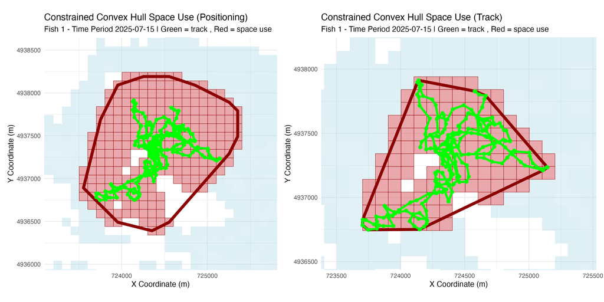

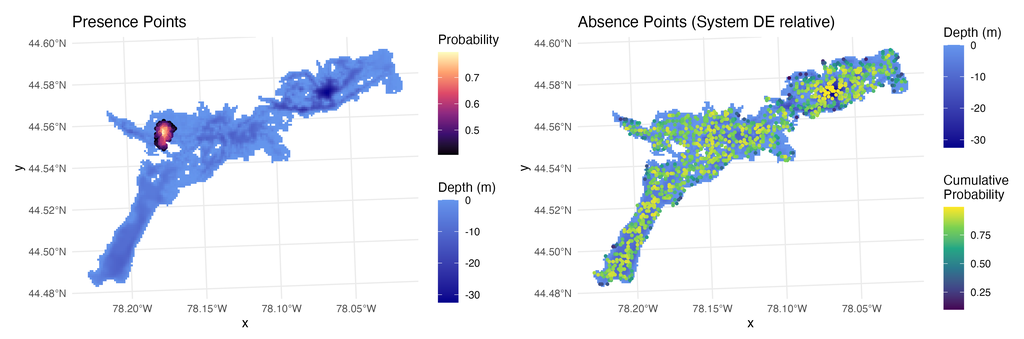

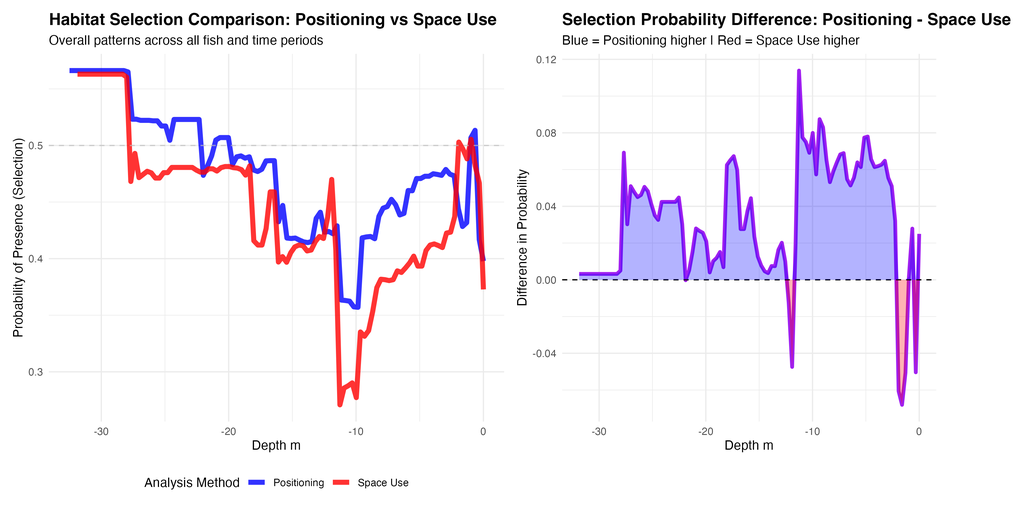

### 🔍 **Visualization & Analysis**

- Comprehensive plotting functions for all analysis types
- Flexible space use visualization
- Detection performance metrics and summaries
- Publication-ready figures and plots

## Installation

Install the development version from GitHub:

```r
# Install devtools if you haven't already
install.packages("devtools")

# Install positionR with vignettes
devtools::install_github("jakebrownscombe/positionR", build_vignettes = TRUE)
```

## Quick Start: Array Design Simulation

```r
library(positionR)

# Load example depth data
data("depth_raster")
raster::crs(depth_raster) <- "EPSG:32617"

# 1. Generate receiver array (100 stations, regularly spaced)
stations <- generate_exact_regular_points(depth_raster, n_points = 100, seed = 123)

# 2. Calculate cost-weighted distances
station_distances <- calculate_station_distances(
  raster = depth_raster,
  receiver_frame = stations,
  max_distance = 30000,
  station_col = "station_id"
)

# 3. Create detection efficiency model
logistic_DE <- create_logistic_curve_depth(
  min_depth = 2, max_depth = 25,
  d50_min_depth = 150, d95_min_depth = 50,
  d50_max_depth = 300, d95_max_depth = 100,
  plot = TRUE
)

# 4. Calculate system detection coverage
system_DE <- calculate_detection_system(
  distance_frame = station_distances,
  receiver_frame = stations,
  model = logistic_DE$log_model,
  threshold = 0.8,
  output_type = "cumulative"
)

# 5. Simulate fish movement with detections
start_time <- as.POSIXct("2025-07-15 12:00:00", tz = "UTC")

fish_simulation <- simulate_fish_tracks(
  raster = depth_raster,
  station_distances = station_distances,
  n_paths = 5,
  n_steps = 1440,  # 24 hours at 60-second intervals
  time_step = 60,
  start_time = start_time,
  species = "walleye"  # Enables behavioral states
)

# 6. Visualize and analyze results
plot_fish_tracks(fish_simulation, depth_raster, stations)
analyze_detection_performance(fish_simulation)
```

## Quick Start: WADE Positioning with Field Data

```r
library(positionR)

# Load field data (included with package)
data("stoney_fish_detections")  # Detection events
data("stoney_rx_deploy")        # Receiver deployments
data("depth_raster")            # Study area bathymetry

# 1. Calculate station distances for WADE positioning
station_distances <- calculate_station_distances(
  raster = depth_raster,
  receiver_frame = stoney_rx_deploy,
  max_distance = 30000,
  station_col = "station_id"
)

# 2. Prepare detection data for WADE analysis
wade_data <- prepare_detection_data_for_wade(
  detection_events = stoney_fish_detections,
  receiver_deployments = stoney_rx_deploy,
  start_time = as.POSIXct("2023-10-15 00:00:00", tz = "UTC"),
  end_time = as.POSIXct("2023-10-29 23:00:00", tz = "UTC"),
  time_aggregation_method = "daily"
)

# 3. Run WADE positioning algorithm
positioning_results <- calculate_fish_positions(
  detection_data = wade_data,
  station_distances = station_distances,
  logistic_model = logistic_DE$log_model,
  positioning_method = "WADE",
  min_det_threshold = 1,
  information_weighting = TRUE,
  crs = "EPSG:32617"
)

# 4. Visualize positioning results
plot_fish_positions(
  positioning_results = positioning_results,
  raster = depth_raster,
  receiver_frame = stoney_rx_deploy,
  plot_type = "integrated",
  time_filter = "2023-10-27"
)
```

## Core Function Categories

### 🎯 **Array Generation**

- `generate_exact_regular_points()` - Specific number of regularly spaced receivers
- `generate_spaced_points()` - Receivers with defined minimum spacing
- `generate_random_points()` - Randomly distributed receivers

### 📡 **Detection Modeling**

- `create_logistic_curve_depth()` - Distance-depth detection efficiency models
- `calculate_station_distances()` - Cost-weighted distance calculations
- `calculate_detection_system()` - System-wide detection probability surfaces

### 🐟 **Movement & Positioning**

- `simulate_fish_tracks()` - Behavioral movement simulation with species parameters
- `prepare_detection_data_for_wade()` - Process field detection data
- `calculate_fish_positions()` - WADE positioning algorithm

### 📈 **Space Use Analysis**

- `calculate_space_use()` - Multiple space use estimation methods
- `generate_random_points_in_space_use()` - Point sampling from space use areas
- `generate_space_use_absences()` - Generate absence points for habitat analysis
- `analyze_comparative_habitat_selection()` - Compare positioning vs tracking data

### 🎨 **Visualization**

- `plot_fish_tracks()` - Movement paths with detection events
- `plot_fish_positions()` - WADE positioning probability surfaces
- `plot_space_use()` - Space use area visualizations
- `plot_behavioral_states()` - Behavioral state time series
- `plot_depth_selection()` - Habitat selection analysis plots

### 📊 **Analysis**

- `analyze_detection_performance()` - Detection system performance metrics
- `analyze_behavioral_temperature()` - Temperature-behavior interactions
- `compare_space_use_thresholds()` - Space use method comparisons

## Included Datasets

- `depth_raster` - Example bathymetry raster for system testing
- `stoney_fish_detections` - Real walleye detection data from Stoney Lake
- `stoney_rx_deploy` - Receiver deployment metadata
- `daily_temperature` - Daily water temperature data for behavioral modeling

## Vignettes & Tutorials

Comprehensive tutorials are available:

```r
# Array design and optimization
vignette("Array_Design_Simulation", package = "positionR")

# WADE positioning methodology
vignette("WADE_Simulation", package = "positionR")

# Field data application
browseVignettes("positionR")
```

## Key Applications

- **🔬 Array Design**: Optimize receiver placement for detection coverage
- **📍 Animal Positioning**: Locate animals using WADE methodology
- **🏠 Habitat Selection**: Analyze space use and habitat preferences
- **🌡️ Behavioral Ecology**: Study temperature-dependent movement patterns
- **📊 System Evaluation**: Assess performance of existing telemetry arrays
- **🎯 Simulation Studies**: Test scenarios and validate methodologies

## Methodology: WADE Positioning

The Weighted Average Detection Efficiency (WADE) methodology provides probabilistic animal positioning by:

1. **Detection Integration**: Combining detection events with receiver-specific detection probabilities
2. **Non-detection Integration**: Incorporating information from receivers that should have detected the animal but didn’t
3. **Temporal Aggregation**: Integrating data across user-defined time periods
4. **Spatial Weighting**: Weighting positions by detection efficiency and detection frequency
5. **Uncertainty Quantification**: Providing probability surfaces rather than point estimates

## Dependencies

Key dependencies include:

- **Spatial**: `raster`, `sf`, `sp`, `gdistance` - spatial data handling and analysis
- **Visualization**: `ggplot2`, `ggridges`, `scales` - publication-quality plots
- **Data**: `dplyr`, `tidyr`, `lubridate` - data manipulation and processing
- **Movement**: `circular`, `FNN` - movement modeling and nearest neighbor calculations
- **Analysis**: `randomForest` - habitat selection modeling

## Citation

If you use positionR in your research, please cite:

```
Brownscombe, J.W. (2025). positionR: Weighted Average Detection Efficiency (WADE)
Positioning for Acoustic Telemetry. R package version 1.0.0.
https://github.com/jakebrownscombe/positionR
```

## Contributing

Contributions are welcome! Please:

1. Fork the repository
2. Create a feature branch (`git checkout -b feature/new-feature`)
3. Commit changes (`git commit -am 'Add new feature'`)
4. Push to branch (`git push origin feature/new-feature`)
5. Create a Pull Request

## License

This project is licensed under the GPL-3 License - see the LICENSE file for details.

## Contact & Support

- **Author**: Dr. Jacob Brownscombe
- **Email**: jakebrownscombe@gmail.com
- **GitHub**: [@jakebrownscombe](https://github.com/jakebrownscombe)
- **Issues**: [Report bugs or request features](https://github.com/jakebrownscombe/positionR/issues)